# Car Insurance Claims Classification Codes

Hamed Vaheb

# 1 **Libraries**

```r
knitr::opts_chunk$set(echo = TRUE)
library(aiinsurance)
library(dplyr)
library(janitor)
```

```r
library(visdat)
library(ggplot2)
library(imbalance)
library(readr)
library(caret) #for dummyVar function
library(Metrics)
library(randomForest)
library(tidyverse)
library(fontawesome)
```

The package developed for this project is the `aiinsurance` package. Instructions on how to install and use the package’s functions and features is provided in the [README part of package’s Github repository](https://github.com/berserkhmdvhb/aiinsurance#readme) .

To install the package quickly, run the following:

```r
#install.packages("devtools")
#library(devtools)
#install_github("berserkhmdvhb/aiinsurance")
```

# 2 **Introduction**

This report is dedicated to project of a workshop of master of data science at University of Luxembourg, for which I built the [`aiinsurance`](https://github.com/berserkhmdvhb/aiinsurance) package.

You can explore the documentation of package I provided with

`help(package="aiinsurance")`

Note that all functions of the package are suffixed with `hmd`.

# 3 **Load Dataset**

To provide a test case on a dataset with discrete target variable, I used the the [car insurance data](https://www.kaggle.com/datasets/sagnik1511/car-insurance-data).

The dataset is embedded in the package, therefore by simply running the following commands one can load and display the dataset. . It can be used by the following syntax:

`data("car_insurance_data")`

```r
data(car_insurance_data)

dplyr::glimpse(car_insurance_data)
```

```
## Rows: 10,000
## Columns: 19
## $ ID                  <int> 569520, 750365, 199901, 478866, 731664, 877557, 93…
## $ AGE                 <chr> "65+", "16-25", "16-25", "16-25", "26-39", "40-64"…
## $ GENDER              <chr> "female", "male", "female", "male", "male", "femal…
## $ RACE                <chr> "majority", "majority", "majority", "majority", "m…
## $ DRIVING_EXPERIENCE  <chr> "0-9y", "0-9y", "0-9y", "0-9y", "10-19y", "20-29y"…
## $ EDUCATION           <chr> "high school", "none", "high school", "university"…
## $ INCOME              <chr> "upper class", "poverty", "working class", "workin…
## $ CREDIT_SCORE        <dbl> 0.6290273, 0.3577571, 0.4931458, 0.2060129, 0.3883…
## $ VEHICLE_OWNERSHIP   <int> 1, 0, 1, 1, 1, 1, 0, 0, 0, 1, 1, 1, 1, 1, 1, 0, 1,…
## $ VEHICLE_YEAR        <chr> "after 2015", "before 2015", "before 2015", "befor…
## $ MARRIED             <int> 0, 0, 0, 0, 0, 0, 1, 0, 1, 0, 1, 1, 1, 0, 1, 1, 1,…
## $ CHILDREN            <int> 1, 0, 0, 1, 0, 1, 1, 1, 0, 1, 1, 0, 1, 1, 1, 0, 1,…
## $ POSTAL_CODE         <int> 10238, 10238, 10238, 32765, 32765, 10238, 10238, 1…
## $ ANNUAL_MILEAGE      <int> 12000, 16000, 11000, 11000, 12000, 13000, 13000, 1…
## $ VEHICLE_TYPE        <chr> "sedan", "sedan", "sedan", "sedan", "sedan", "seda…
## $ SPEEDING_VIOLATIONS <int> 0, 0, 0, 0, 2, 3, 7, 0, 0, 0, 6, 4, 4, 0, 0, 0, 10…
## $ DUIS                <int> 0, 0, 0, 0, 0, 0, 0, 0, 0, 0, 2, 0, 1, 0, 2, 0, 2,…
## $ PAST_ACCIDENTS      <int> 0, 0, 0, 0, 1, 3, 3, 0, 0, 0, 7, 0, 2, 0, 1, 0, 1,…
## $ OUTCOME             <int> 0, 1, 0, 0, 1, 0, 0, 1, 0, 1, 0, 0, 0, 0, 0, 0, 0,…
```

Summary of statistical properties of columns are provided in the following:

```r
summary(car_insurance_data)
```

```
##        ID             AGE               GENDER              RACE
##  Min.   :   101   Length:10000       Length:10000       Length:10000
##  1st Qu.:249638   Class :character   Class :character   Class :character
##  Median :501777   Mode  :character   Mode  :character   Mode  :character
##  Mean   :500522
##  3rd Qu.:753974
##  Max.   :999976
##
##  DRIVING_EXPERIENCE  EDUCATION            INCOME           CREDIT_SCORE
##  Length:10000       Length:10000       Length:10000       Min.   :0.0534
##  Class :character   Class :character   Class :character   1st Qu.:0.4172
##  Mode  :character   Mode  :character   Mode  :character   Median :0.5250
##                                                           Mean   :0.5158
##                                                           3rd Qu.:0.6183
##                                                           Max.   :0.9608
##                                                           NA's   :982
##  VEHICLE_OWNERSHIP VEHICLE_YEAR          MARRIED          CHILDREN
##  Min.   :0.000     Length:10000       Min.   :0.0000   Min.   :0.0000
##  1st Qu.:0.000     Class :character   1st Qu.:0.0000   1st Qu.:0.0000
##  Median :1.000     Mode  :character   Median :0.0000   Median :1.0000
##  Mean   :0.697                        Mean   :0.4982   Mean   :0.6888
##  3rd Qu.:1.000                        3rd Qu.:1.0000   3rd Qu.:1.0000
##  Max.   :1.000                        Max.   :1.0000   Max.   :1.0000
##
##   POSTAL_CODE    ANNUAL_MILEAGE  VEHICLE_TYPE       SPEEDING_VIOLATIONS
##  Min.   :10238   Min.   : 2000   Length:10000       Min.   : 0.000
##  1st Qu.:10238   1st Qu.:10000   Class :character   1st Qu.: 0.000
##  Median :10238   Median :12000   Mode  :character   Median : 0.000
##  Mean   :19865   Mean   :11697                      Mean   : 1.483
##  3rd Qu.:32765   3rd Qu.:14000                      3rd Qu.: 2.000
##  Max.   :92101   Max.   :22000                      Max.   :22.000
##                  NA's   :957
##       DUIS        PAST_ACCIDENTS      OUTCOME
##  Min.   :0.0000   Min.   : 0.000   Min.   :0.0000
##  1st Qu.:0.0000   1st Qu.: 0.000   1st Qu.:0.0000
##  Median :0.0000   Median : 0.000   Median :0.0000
##  Mean   :0.2392   Mean   : 1.056   Mean   :0.3133
##  3rd Qu.:0.0000   3rd Qu.: 2.000   3rd Qu.:1.0000
##  Max.   :6.0000   Max.   :15.000   Max.   :1.0000
##
```

# 4 **Preprocess**

Before feeding data to the model, various preprocessing stages are performed in the following subsections:

## 4.1 Clean Column Names

```r
df <- janitor::clean_names(car_insurance_data)

names(df)
```

```
##  [1] "id"                  "age"                 "gender"
##  [4] "race"                "driving_experience"  "education"
##  [7] "income"              "credit_score"        "vehicle_ownership"
## [10] "vehicle_year"        "married"             "children"
## [13] "postal_code"         "annual_mileage"      "vehicle_type"
## [16] "speeding_violations" "duis"                "past_accidents"
## [19] "outcome"
```

```r
df |> dplyr::glimpse()
```

```
## Rows: 10,000
## Columns: 19
## $ id                  <int> 569520, 750365, 199901, 478866, 731664, 877557, 93…
## $ age                 <chr> "65+", "16-25", "16-25", "16-25", "26-39", "40-64"…
## $ gender              <chr> "female", "male", "female", "male", "male", "femal…
## $ race                <chr> "majority", "majority", "majority", "majority", "m…
## $ driving_experience  <chr> "0-9y", "0-9y", "0-9y", "0-9y", "10-19y", "20-29y"…
## $ education           <chr> "high school", "none", "high school", "university"…
## $ income              <chr> "upper class", "poverty", "working class", "workin…
## $ credit_score        <dbl> 0.6290273, 0.3577571, 0.4931458, 0.2060129, 0.3883…
## $ vehicle_ownership   <int> 1, 0, 1, 1, 1, 1, 0, 0, 0, 1, 1, 1, 1, 1, 1, 0, 1,…
## $ vehicle_year        <chr> "after 2015", "before 2015", "before 2015", "befor…
## $ married             <int> 0, 0, 0, 0, 0, 0, 1, 0, 1, 0, 1, 1, 1, 0, 1, 1, 1,…
## $ children            <int> 1, 0, 0, 1, 0, 1, 1, 1, 0, 1, 1, 0, 1, 1, 1, 0, 1,…
## $ postal_code         <int> 10238, 10238, 10238, 32765, 32765, 10238, 10238, 1…
## $ annual_mileage      <int> 12000, 16000, 11000, 11000, 12000, 13000, 13000, 1…
## $ vehicle_type        <chr> "sedan", "sedan", "sedan", "sedan", "sedan", "seda…
## $ speeding_violations <int> 0, 0, 0, 0, 2, 3, 7, 0, 0, 0, 6, 4, 4, 0, 0, 0, 10…
## $ duis                <int> 0, 0, 0, 0, 0, 0, 0, 0, 0, 0, 2, 0, 1, 0, 2, 0, 2,…
## $ past_accidents      <int> 0, 0, 0, 0, 1, 3, 3, 0, 0, 0, 7, 0, 2, 0, 1, 0, 1,…
## $ outcome             <int> 0, 1, 0, 0, 1, 0, 0, 1, 0, 1, 0, 0, 0, 0, 0, 0, 0,…
```

```r
set.seed(12345)
```

## 4.2 Categorical Columns

We need to factorise the categorical columns, which can be done by merely inputting columns intended to be converted in `cat_cols` in the `prepare_hmd` function. Before doing that, we report and visualise the nature of categorical data and their frequency in the dataset

List of categorical columns containing characters:

```r
categoricals_print_hmd(df)
```

```
## [1] "List of categorical columns containing characters: "
## [1] "age"                "gender"             "race"
## [4] "driving_experience" "education"          "income"
## [7] "vehicle_year"       "vehicle_type"
## [1] "List of categorical columns containing numbers: "
## [1] "vehicle_ownership" "married"           "children"
## [4] "postal_code"       "outcome"
```

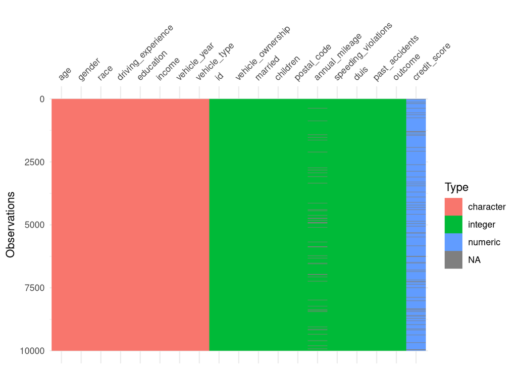

```r
vis_dat(df)
```

```r
df <- categoricals_hmd(df)
dplyr::glimpse(df)
```

```
## Rows: 10,000
## Columns: 19
## $ id                  <int> 569520, 750365, 199901, 478866, 731664, 877557, 93…
## $ age                 <fct> 65+, 16-25, 16-25, 16-25, 26-39, 40-64, 65+, 26-39…
## $ gender              <fct> female, male, female, male, male, female, male, fe…
## $ race                <fct> majority, majority, majority, majority, majority, …
## $ driving_experience  <fct> 0-9y, 0-9y, 0-9y, 0-9y, 10-19y, 20-29y, 30y+, 0-9y…
## $ education           <fct> high school, none, high school, university, none, …
## $ income              <fct> upper class, poverty, working class, working class…
## $ credit_score        <dbl> 0.6290273, 0.3577571, 0.4931458, 0.2060129, 0.3883…
## $ vehicle_ownership   <int> 1, 0, 1, 1, 1, 1, 0, 0, 0, 1, 1, 1, 1, 1, 1, 0, 1,…
## $ vehicle_year        <fct> after 2015, before 2015, before 2015, before 2015,…
## $ married             <int> 0, 0, 0, 0, 0, 0, 1, 0, 1, 0, 1, 1, 1, 0, 1, 1, 1,…
## $ children            <int> 1, 0, 0, 1, 0, 1, 1, 1, 0, 1, 1, 0, 1, 1, 1, 0, 1,…
## $ postal_code         <int> 10238, 10238, 10238, 32765, 32765, 10238, 10238, 1…
## $ annual_mileage      <int> 12000, 16000, 11000, 11000, 12000, 13000, 13000, 1…
## $ vehicle_type        <fct> sedan, sedan, sedan, sedan, sedan, sedan, sedan, s…
## $ speeding_violations <int> 0, 0, 0, 0, 2, 3, 7, 0, 0, 0, 6, 4, 4, 0, 0, 0, 10…
## $ duis                <int> 0, 0, 0, 0, 0, 0, 0, 0, 0, 0, 2, 0, 1, 0, 2, 0, 2,…
## $ past_accidents      <int> 0, 0, 0, 0, 1, 3, 3, 0, 0, 0, 7, 0, 2, 0, 1, 0, 1,…
## $ outcome             <int> 0, 1, 0, 0, 1, 0, 0, 1, 0, 1, 0, 0, 0, 0, 0, 0, 0,…
```

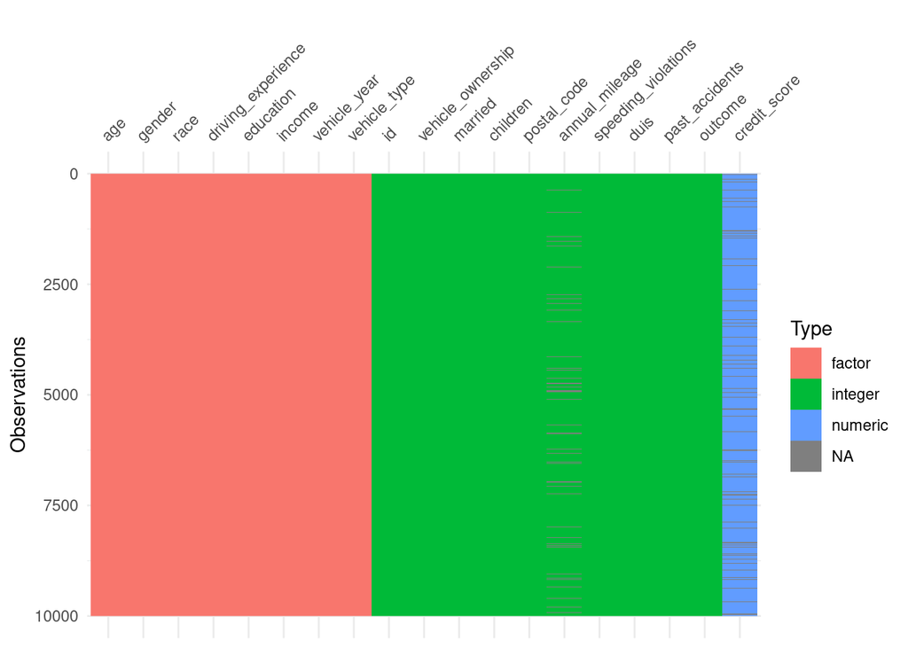

```r
vis_dat(df)
```